# Pronósticos: SES, Holt, HW(M), Damped(A)

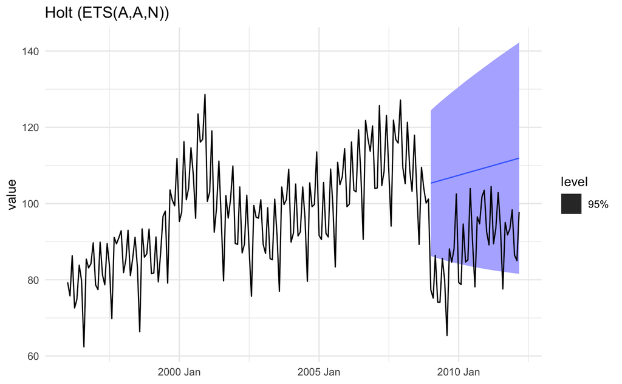

```r
p_holt
```

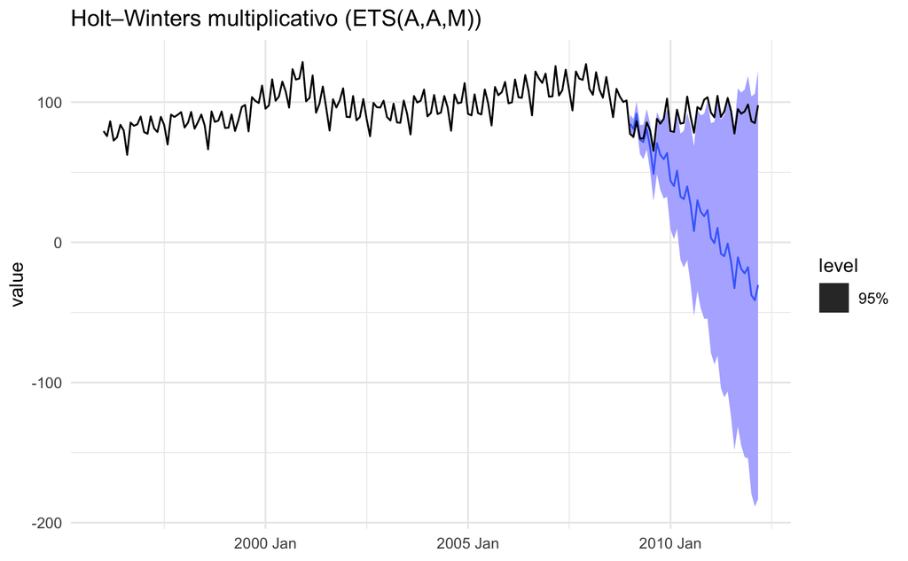

```r
p_hw
```

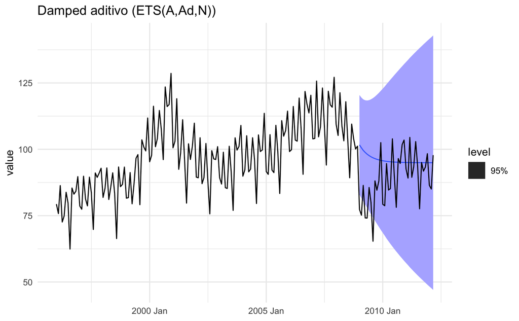

```r
p_damp
```

# Métricas de error para test

```r
# in-sample one-step
acc_test  <- accuracy(fc, test)        # out-of-sample
library(DT)
datatable(acc_test %>%
            select(.model, ME:MAPE),
          caption = "Métricas en prueba (holdout)") %>%
  formatRound(columns = c("ME","RMSE","MAE","MPE","MAPE"),
              digits = 3)
```

|  | .model | ME | RMSE | MAE | MPE | MAPE |
| --- | --- | --- | --- | --- | --- | --- |
| 1 | DT | -7.16915517752476 | 12.76661515947763 | 10.02087966235403 | -9.515347942783729 | 12.29791351672365 |
| 2 | HOLT | -19.81924825947865 | 21.64576858031939 | 19.81924825947865 | -23.68067211741325 | 23.68067211741325 |
| 3 | HW | 63.39515545209773 | 76.41925430387991 | 64.33025849241635 | 69.16727943913764 | 70.34956513889036 |
| 4 | SES | -15.44209977358179 | 18.1639507131378 | 15.45408939729028 | -18.82645952946773 | 18.83793504986254 |

Tomamos como métrica de referecnia RMSE y observamos que el mejor modelo es el de tenendencia amortiguada lo cual sugiere que que la pendiente aporta, pero la proyección conservadora funciona mejor fuera de muestra.

Recomendación: Priorizar **presupuestos conservadores** a mediano y largo plazo; revisa políticas de **reposición** para evitar sobrestock

Nota: **Damped (A)** proyecta tendencia **sin exagerar**, ideal para presupuestos y decisiones donde el costo de sobreestimar es alto.